# University Faculty Salary Analysis

Álvaro Granados Villodre

2025-May

## **Introduction**

This analysis examines the factors influencing university faculty salaries using the “Salaries” dataset from the “car” package in R. The primary objective is to develop and evaluate **Gaussian linear models** to predict faculty salaries based mainly on professional characteristics. Through systematic model development and validation, this study seeks to identify the **most significant predictors of academic compensation** and offer insights into the mechanisms behind salary determination in higher education.

To achieve this, multiple linear regression models have been implemented to explore the relationships between variables, with particular attention to **multicollinearity and predictive performance**. The analysis also includes transformations to capture potential non-linear patterns in the data.

The dataset contains information about 397 university professors with the following variables:

- **rank**: three levels of professor positions (AsstProf, AssocProf, Prof)
- **discipline**: type of teaching discipline (A, B)
- **yrs.since.phd**: years since PhD completion
- **yrs.service**: years of service
- **sex**: gender (Female, Male)
- **salary**: salary in dollars

```r
library(carData)
data(Salaries)
str(Salaries)
```

```
## 'data.frame':    397 obs. of  6 variables:
##  $ rank         : Factor w/ 3 levels "AsstProf","AssocProf",..: 3 3 1 3 3 2 3 3 3 3 ...
##  $ discipline   : Factor w/ 2 levels "A","B": 2 2 2 2 2 2 2 2 2 2 ...
##  $ yrs.since.phd: int  19 20 4 45 40 6 30 45 21 18 ...
##  $ yrs.service  : int  18 16 3 39 41 6 23 45 20 18 ...
##  $ sex          : Factor w/ 2 levels "Female","Male": 2 2 2 2 2 2 2 2 2 1 ...
##  $ salary       : int  139750 173200 79750 115000 141500 97000 175000 147765 119250 129000 ...
```

```r
summary(Salaries)
```

```
##         rank     discipline yrs.since.phd    yrs.service        sex
##  AsstProf : 67   A:181      Min.   : 1.00   Min.   : 0.00   Female: 39
##  AssocProf: 64   B:216      1st Qu.:12.00   1st Qu.: 7.00   Male  :358
##  Prof     :266              Median :21.00   Median :16.00
##                             Mean   :22.31   Mean   :17.61
##                             3rd Qu.:32.00   3rd Qu.:27.00
##                             Max.   :56.00   Max.   :60.00
##      salary
##  Min.   : 57800
##  1st Qu.: 91000
##  Median :107300
##  Mean   :113706
##  3rd Qu.:134185
##  Max.   :231545
```

## **Exploratory Analysis**

This section performs a visual analysis to better understand the relationships between key variables, specifically examining how years of service and years since PhD relate to faculty salaries.

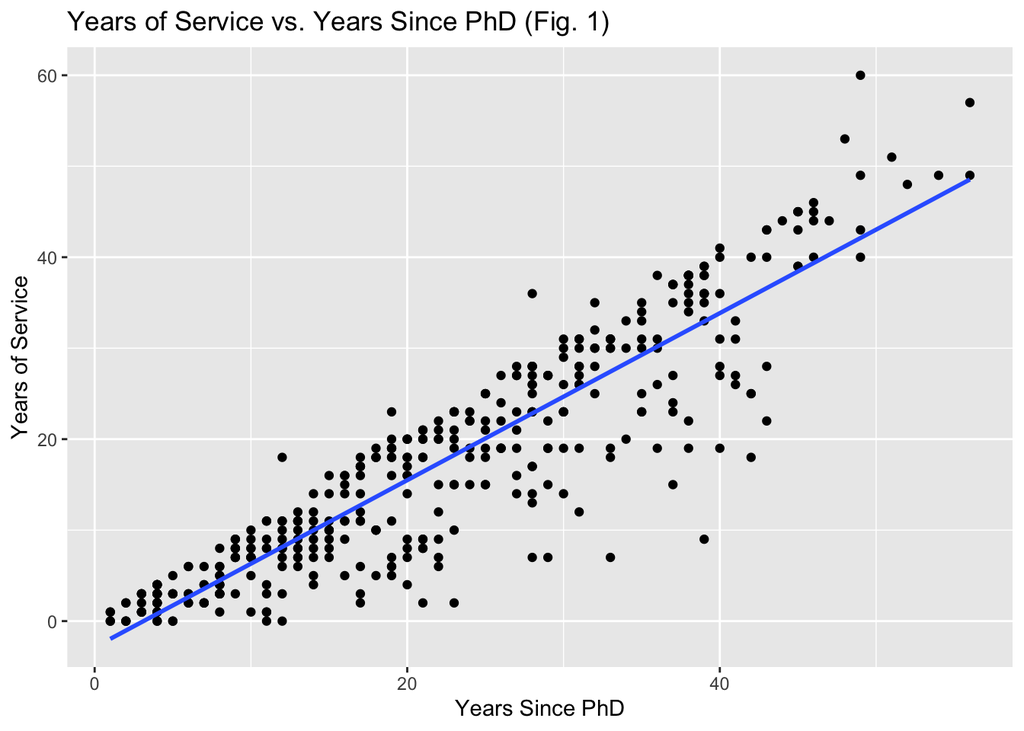

```r
library(ggplot2)

# Plot yrs.service vs. yrs.since.phd
ggplot(Salaries, aes(x = yrs.since.phd, y = yrs.service)) +
  geom_point() +
  geom_smooth(method = "lm", se = FALSE) +
  labs(title = "Years of Service vs. Years Since PhD (Fig. 1)",
       x = "Years Since PhD",
       y = "Years of Service")
```

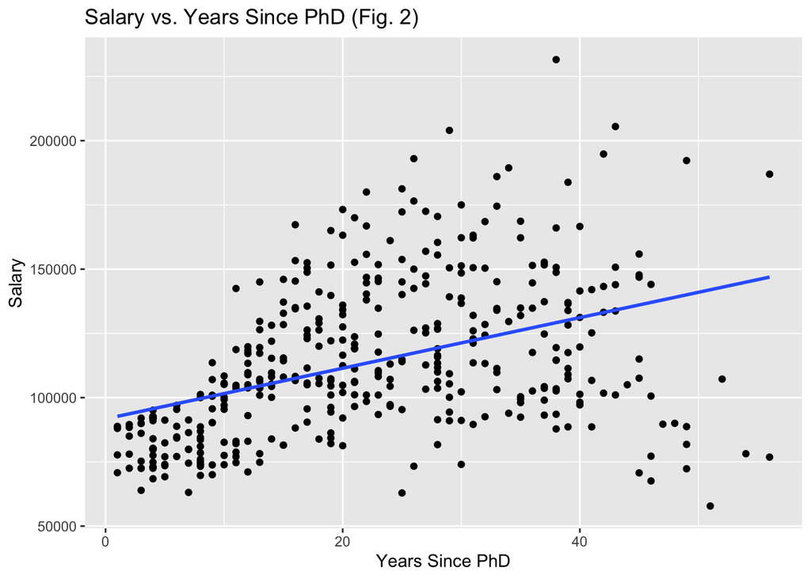

```r
# Plot salary vs. yrs.since.phd
ggplot(Salaries, aes(x = yrs.since.phd, y = salary)) +
  geom_point() +
  geom_smooth(method = "lm", se = FALSE) +
  labs(title = "Salary vs. Years Since PhD (Fig. 2)",
       x = "Years Since PhD",
       y = "Salary")
```

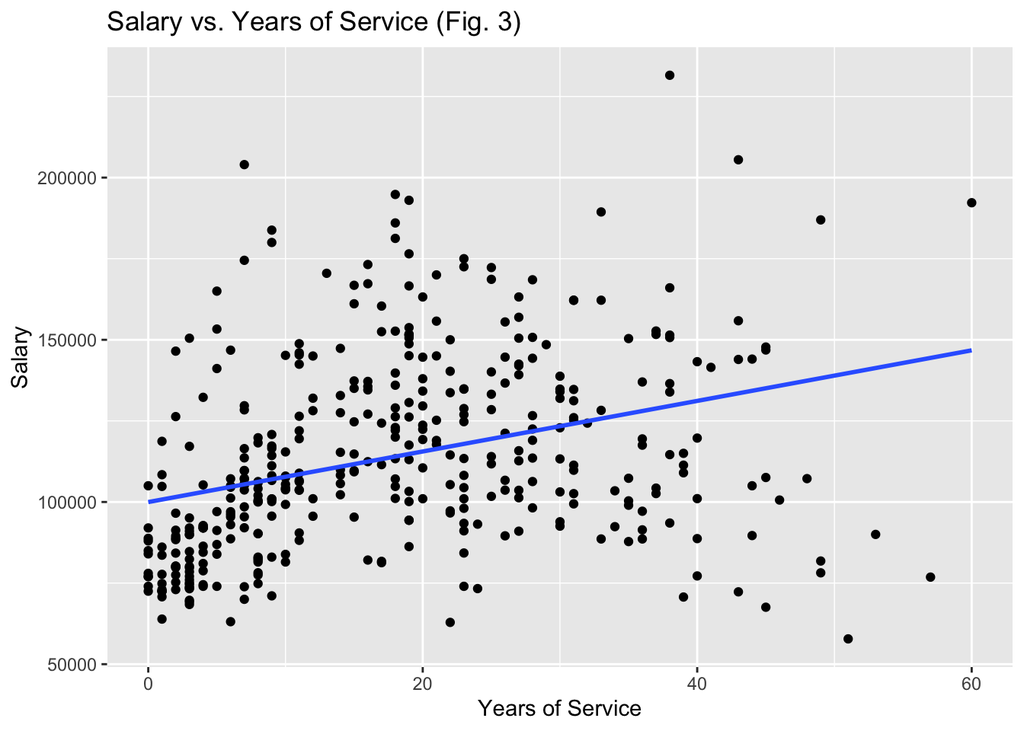

```r
# Plot salary vs. yrs.service
ggplot(Salaries, aes(x = yrs.service, y = salary)) +
  geom_point() +
  geom_smooth(method = "lm", se = FALSE) +
  labs(title = "Salary vs. Years of Service (Fig. 3)",
       x = "Years of Service",
       y = "Salary")
```

The scatter plots reveal positive linear trends between salary and both years since PhD and years of service. However, a strong correlation between years of service and years since PhD is also observed (Fig. 1), suggesting the **presence of collinearity** between these variables.

## **Initial Regression Model**

The first approach involves training a basic linear regression model that explains salary as a function of years of service and years since PhD.

```r
formula_salary_vs_yrs = as.formula(salary ~ yrs.since.phd + yrs.service)
lmmodel_salary_vs_yrs <- lm(formula_salary_vs_yrs, data = Salaries)
summary(lmmodel_salary_vs_yrs)
```

```
##
## Call:
## lm(formula = formula_salary_vs_yrs, data = Salaries)
##
## Residuals:
##    Min     1Q Median     3Q    Max
## -79735 -19823  -2617  15149 106149
##
## Coefficients:
##               Estimate Std. Error t value Pr(>|t|)
## (Intercept)    89912.2     2843.6  31.620  < 2e-16 ***
## yrs.since.phd   1562.9      256.8   6.086 2.75e-09 ***
## yrs.service     -629.1      254.5  -2.472   0.0138 *
## ---
## Signif. codes:  0 '***' 0.001 '**' 0.01 '*' 0.05 '.' 0.1 ' ' 1
##
## Residual standard error: 27360 on 394 degrees of freedom
## Multiple R-squared:  0.1883, Adjusted R-squared:  0.1842
## F-statistic: 45.71 on 2 and 394 DF,  p-value: < 2.2e-16
```

The initial model results present interesting findings. The positive coefficient for “**yrs.since.phd**” (1562.9) shows that salary rises with years since earning a PhD, which aligns with expectations. Conversely, the negative coefficient for “**yrs.service**” (-629.1) points to an unexpected salary decrease with longer years of service, likely due to **collinearity between these variables**, as illustrated in Figure 1.

The residual standard error of 27.360 represents the average deviation between observed and predicted salaries. With an R² of 0.1883 and an adjusted R² of 0.1842, **the model explains only about 18% of the variance in salary, indicating limited explanatory power.**

## **Gender Incorporation**

To evaluate whether gender improves the predictive model, this categorical variable has been incorporated into the analysis.

```r
formula_salary_vs_yrs_sex = as.formula(salary ~ yrs.since.phd + yrs.service + sex)
lmmodel_salary_vs_yrs_sex <- lm(formula_salary_vs_yrs_sex, data = Salaries)
summary(lmmodel_salary_vs_yrs_sex)
```

```
##
## Call:
## lm(formula = formula_salary_vs_yrs_sex, data = Salaries)
##
## Residuals:
##    Min     1Q Median     3Q    Max
## -79586 -19564  -3018  15071 105898
##
## Coefficients:
##               Estimate Std. Error t value Pr(>|t|)
## (Intercept)    82875.9     4800.6  17.264  < 2e-16 ***
## yrs.since.phd   1552.8      256.1   6.062 3.15e-09 ***
## yrs.service     -649.8      254.0  -2.558   0.0109 *
## sexMale         8457.1     4656.1   1.816   0.0701 .
## ---
## Signif. codes:  0 '***' 0.001 '**' 0.01 '*' 0.05 '.' 0.1 ' ' 1
##
## Residual standard error: 27280 on 393 degrees of freedom
## Multiple R-squared:  0.1951, Adjusted R-squared:  0.189
## F-statistic: 31.75 on 3 and 393 DF,  p-value: < 2.2e-16
```

**The inclusion of gender (represented by the *sexMale* variable) does not considerably improve the model.** The average residual error remains practically constant (27.280 vs 27.360), and the remaining coefficients stay at similar values. The adjusted coefficient of determination increases minimally from 0.1842 to 0.189, indicating that gender does not provide additional relevant information for predicting salary.

## **Scale Transformations**

To better understand coefficient behavior, different transformations of the dependent variable have been explored. First, salary has been expressed in thousands of dollars.

```r
Salaries$salary1000 <- Salaries$salary / 1000
formula_salary1000_vs_yrs = as.formula(salary1000 ~ yrs.since.phd + yrs.service)
lmmodel_salary1000_vs_yrs <- lm(formula_salary1000_vs_yrs, data = Salaries)
summary(lmmodel_salary1000_vs_yrs)
```

```
##
## Call:
## lm(formula = formula_salary1000_vs_yrs, data = Salaries)
##
## Residuals:
##     Min      1Q  Median      3Q     Max
## -79.735 -19.823  -2.617  15.149 106.149
##
## Coefficients:
##               Estimate Std. Error t value Pr(>|t|)
## (Intercept)    89.9122     2.8436  31.620  < 2e-16 ***
## yrs.since.phd   1.5629     0.2568   6.086 2.75e-09 ***
## yrs.service    -0.6291     0.2545  -2.472   0.0138 *
## ---
## Signif. codes:  0 '***' 0.001 '**' 0.01 '*' 0.05 '.' 0.1 ' ' 1
##
## Residual standard error: 27.36 on 394 degrees of freedom
## Multiple R-squared:  0.1883, Adjusted R-squared:  0.1842
## F-statistic: 45.71 on 2 and 394 DF,  p-value: < 2.2e-16
```

As expected, when dividing salary by 1000, all betas are proportionally divided by the same factor. This linear transformation does not alter the fundamental relationships of the model, only changes the interpretation scale.

Subsequently, a logarithmic transformation has been applied to salary to explore non-linear relationships.

```r
Salaries$salaryln <- log(Salaries$salary)
formula_salaryln_vs_yrs = as.formula(salaryln ~ yrs.since.phd + yrs.service)
lmmodel_salaryln_vs_yrs <- lm(formula_salaryln_vs_yrs, data = Salaries)
summary(lmmodel_salaryln_vs_yrs)
```

```
##
## Call:
## lm(formula = formula_salaryln_vs_yrs, data = Salaries)
##
## Residuals:
##      Min       1Q   Median       3Q      Max
## -0.85152 -0.17076 -0.00342  0.15606  0.64229
##
## Coefficients:
##                Estimate Std. Error t value Pr(>|t|)
## (Intercept)   11.400345   0.024352 468.150  < 2e-16 ***
## yrs.since.phd  0.013471   0.002199   6.125  2.2e-09 ***
## yrs.service   -0.005316   0.002179  -2.439   0.0152 *
## ---
## Signif. codes:  0 '***' 0.001 '**' 0.01 '*' 0.05 '.' 0.1 ' ' 1
##
## Residual standard error: 0.2343 on 394 degrees of freedom
## Multiple R-squared:  0.1932, Adjusted R-squared:  0.1892
## F-statistic: 47.19 on 2 and 394 DF,  p-value: < 2.2e-16
```

The **logarithmic transformation maintains the signs of the betas** but significantly reduces their magnitudes. The negative coefficient for years of service (-0.005316) persists, confirming the presence of collinearity. In this transformed model, each additional year of service is associated with a 0.53% decrease in salary.

## **Development of an Improved Model**

To develop a more robust model, a correlation analysis has been performed between all available variables, including categorical variables converted to dummy variables.

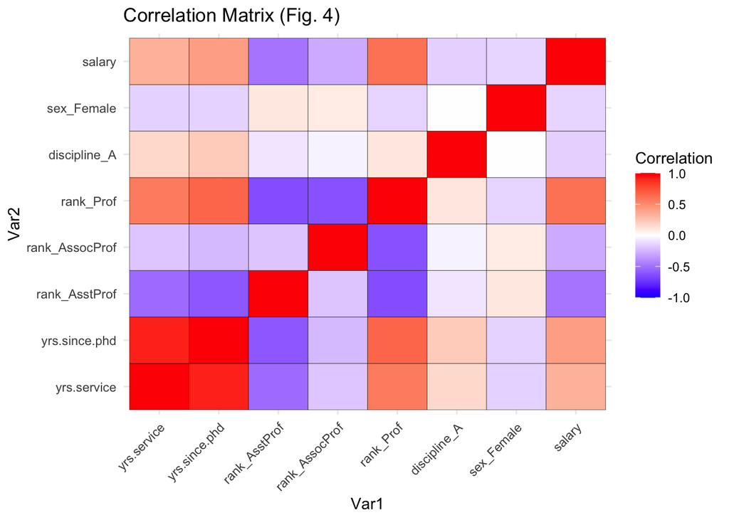

```r
library(ggplot2)
library(reshape2)
library(fastDummies)

# Create dummy variables
dummy_columns <- c('rank', 'discipline', 'sex')
salaries_with_dummies_df <- fastDummies::dummy_cols(Salaries, select_columns = dummy_columns)
model_vars <- c('yrs.service', 'yrs.since.phd', 'rank_AsstProf', 'rank_AssocProf', 'rank_Prof', 'discipline_A','sex_Female', 'salary')

# Get correlations
cor_matrix_dummies <- cor(salaries_with_dummies_df[model_vars])
melted_cor_dummies <- melt(cor_matrix_dummies)

# Visualize correlation matrix
plot_heatmap <- function(melted_cor){
ggplot(data = melted_cor, aes(Var1, Var2, fill = value)) +
  geom_tile(color = "black") +
  scale_fill_gradient2(low = "blue", high = "red", mid = "white",
                       midpoint = 0, limit = c(-1,1), name = "Correlation") +
  theme_minimal() +
  theme(axis.text.x = element_text(angle = 45, vjust = 1, hjust = 1)) +
  ggtitle("Correlation Matrix (Fig. 4)")
}
plot_heatmap(melted_cor_dummies)
```

Based on this analysis, a model has been developed that includes statistically significant variables while avoiding multicollinearity.

```r
formula_lm <- as.formula(salary ~ sex_Female + yrs.since.phd + rank_Prof + rank_AssocProf + discipline_A)
model_lm <- lm(formula_lm, data = salaries_with_dummies_df)
summary(model_lm)
```

```
##
## Call:
## lm(formula = formula_lm, data = salaries_with_dummies_df)
##
## Residuals:
##    Min     1Q Median     3Q    Max
## -67451 -13860  -1549  10716  97023
##
## Coefficients:
##                 Estimate Std. Error t value Pr(>|t|)
## (Intercept)     86171.16    3000.42  28.720  < 2e-16 ***
## sex_Female      -4349.37    3875.39  -1.122  0.26242
## yrs.since.phd      61.01     127.01   0.480  0.63124
## rank_Prof       46032.55    4240.12  10.856  < 2e-16 ***
## rank_AssocProf  13104.15    4167.31   3.145  0.00179 **
## discipline_A   -13937.47    2346.53  -5.940 6.32e-09 ***
## ---
## Signif. codes:  0 '***' 0.001 '**' 0.01 '*' 0.05 '.' 0.1 ' ' 1
##
## Residual standard error: 22660 on 391 degrees of freedom
## Multiple R-squared:  0.4472, Adjusted R-squared:  0.4401
## F-statistic: 63.27 on 5 and 391 DF,  p-value: < 2.2e-16
```

This improved model shows a significant reduction in average residual error (from 27,280 to 22,660) and a considerable increase in explanatory capacity, with R² and adjusted R² increasing from 18% to 44%. The variables rank_Prof, rank_AssocProf, and discipline_A prove to be statistically significant (p < 0.05).

Based on these results, a final model has been developed using logarithmic transformation of salary and the most significant variables.

```r
formula_lm_transformed <- as.formula(salaryln ~ rank_Prof + rank_AssocProf + discipline_A)
model_lm_transformed <- lm(formula_lm_transformed, data = salaries_with_dummies_df)
summary(model_lm_transformed)
```

```
##
## Call:
## lm(formula = formula_lm_transformed, data = salaries_with_dummies_df)
##
## Residuals:
##      Min       1Q   Median       3Q      Max
## -0.69579 -0.11128 -0.00407  0.09423  0.57267
##
## Coefficients:
##                Estimate Std. Error t value Pr(>|t|)
## (Intercept)    11.34107    0.02316 489.679  < 2e-16 ***
## rank_Prof       0.44986    0.02496  18.021  < 2e-16 ***
## rank_AssocProf  0.15058    0.03177   4.739 3.01e-06 ***
## discipline_A   -0.13040    0.01842  -7.079 6.72e-12 ***
## ---
## Signif. codes:  0 '***' 0.001 '**' 0.01 '*' 0.05 '.' 0.1 ' ' 1
##
## Residual standard error: 0.1817 on 393 degrees of freedom
## Multiple R-squared:  0.5159, Adjusted R-squared:  0.5122
## F-statistic: 139.6 on 3 and 393 DF,  p-value: < 2.2e-16
```

This final model presents an average residual error of 0.1817 (on logarithmic scale) and an adjusted **R² of 0.5122, representing a substantial improvement in the model’s predictive power.**

## **Automatic Variable Selection**

To validate the variable selection approach, the stepwise method has been applied starting from all available variables.

```r
formula_all <- as.formula(salary ~ yrs.service + yrs.since.phd + rank_AsstProf + rank_AssocProf + rank_Prof + discipline_A + sex_Female + sex_Male)
model_lm_all <- lm(formula_all, data = salaries_with_dummies_df)
model_stepwise <- step(model_lm_all, direction = "both", k = 0)
```

```
## Start:  AIC=7951.19
## salary ~ yrs.service + yrs.since.phd + rank_AsstProf + rank_AssocProf +
##     rank_Prof + discipline_A + sex_Female + sex_Male
##
##
## Step:  AIC=7951.19
## salary ~ yrs.service + yrs.since.phd + rank_AsstProf + rank_AssocProf +
##     rank_Prof + discipline_A + sex_Female
##
##
## Step:  AIC=7951.19
## salary ~ yrs.service + yrs.since.phd + rank_AsstProf + rank_AssocProf +
##     discipline_A + sex_Female
##
##                  Df  Sum of Sq        RSS    AIC
## <none>                         1.9812e+11 7951.2
## - sex_Female      1 7.8068e+08 1.9890e+11 7952.8
## - yrs.since.phd   1 2.5041e+09 2.0062e+11 7956.2
## - yrs.service     1 2.7100e+09 2.0083e+11 7956.6
## - discipline_A    1 1.9237e+10 2.1735e+11 7988.0
## - rank_AssocProf  1 4.1906e+10 2.4002e+11 8027.4
## - rank_AsstProf   1 5.7455e+10 2.5557e+11 8052.3
```

```r
summary(model_stepwise)
```

```
##
## Call:
## lm(formula = salary ~ yrs.service + yrs.since.phd + rank_AsstProf +
##     rank_AssocProf + discipline_A + sex_Female, data = salaries_with_dummies_df)
##
## Residuals:
##    Min     1Q Median     3Q    Max
## -65248 -13211  -1775  10384  99592
##
## Coefficients:
##                Estimate Std. Error t value Pr(>|t|)
## (Intercept)    130222.3     3907.3  33.328  < 2e-16 ***
## yrs.service      -489.5      211.9  -2.310   0.0214 *
## yrs.since.phd     535.1      241.0   2.220   0.0270 *
## rank_AsstProf  -45066.0     4237.5 -10.635  < 2e-16 ***
## rank_AssocProf -32158.4     3540.6  -9.083  < 2e-16 ***
## discipline_A   -14417.6     2342.9  -6.154 1.88e-09 ***
## sex_Female      -4783.5     3858.7  -1.240   0.2158
## ---
## Signif. codes:  0 '***' 0.001 '**' 0.01 '*' 0.05 '.' 0.1 ' ' 1
##
## Residual standard error: 22540 on 390 degrees of freedom
## Multiple R-squared:  0.4547, Adjusted R-squared:  0.4463
## F-statistic:  54.2 on 6 and 390 DF,  p-value: < 2.2e-16
```

## **Final Model Validation**

To validate the robustness of the final model (model_lm_transformed), a residual analysis has been performed to verify linear regression model assumptions.

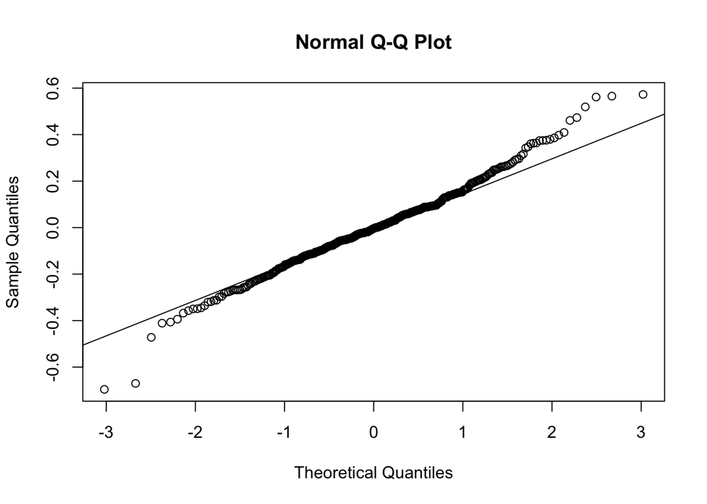

```r
residuals <- model_lm_transformed$resid

# Check normality of residuals
qqnorm(residuals)
qqline(residuals)
```

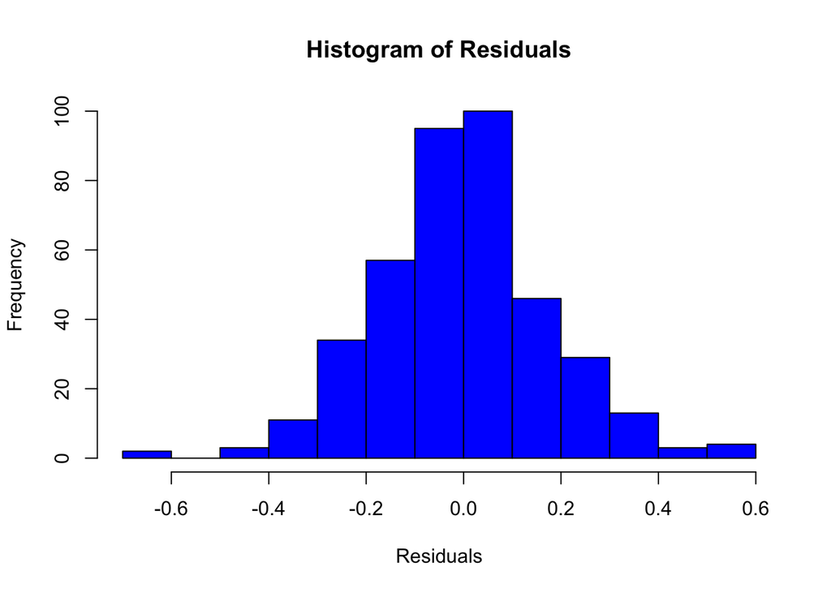

```r
# Histogram of residuals
hist(residuals,
     breaks = "Sturges",
     main = "Histogram of Residuals",
     xlab = "Residuals",
     ylab = "Frequency",
     col = "blue",
     border = "black")
```

```r
# Jarque-Bera test
library(tseries)
jarque.bera.test(residuals)
```

```
##
##  Jarque Bera Test
##
## data:  residuals
## X-squared = 19.524, df = 2, p-value = 5.761e-05
```

```r
# Shapiro-Wilk test
shapiro.test(residuals)
```

```
##
##  Shapiro-Wilk normality test
##
## data:  residuals
## W = 0.98778, p-value = 0.002056
```

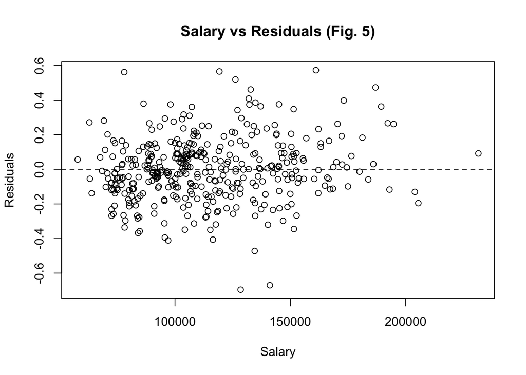

```r
# Independence of residuals
plot(residuals~Salaries$salary[order(Salaries$salary)],
     main="Salary vs Residuals (Fig. 5)",
     xlab="Salary", ylab="Residuals")
abline(h=0, lty=2)
```

```r
# Breusch-Pagan test for heteroscedasticity
library(lmtest)
bptest(model_lm_transformed)
```

```
##
##  studentized Breusch-Pagan test
##
## data:  model_lm_transformed
## BP = 34.041, df = 3, p-value = 1.942e-07
```

The QQ-plot and histogram of residuals show a close approximation to a normal distribution. However, the statistic obtained through the Jarque-Bera test indicates that we can reject the null hypothesis of normality. **This test contradicts what can be visually appreciated through the graphs.**

## **Conclusions**

This analysis provides a solid foundation for understanding the determining factors of university salaries and can serve as a starting point for deeper research on salary equity and compensation policies in the academic environment.